# PyTorch tutorial

This notebook serves as a tutorial for a beginner pytorch programmer and hence walks him/her through the process of making a program that detects if a patient has COVID-19 from an x-ray image

# The imports

First we import all of the necessary libraries to use in this project. We need numpy and pandas for dataloading, sklearn for preprocessing, PIL to work with images, matplotlib to eventually draw graphs, and of course, PyTorch. If you are not familiar with the other tools, it is recommended to gain some familiarity with them, as they form a base ecosystem in which most scientific computing is done in Python. Do not let the multitudes of imports intimidate you, you'll see where they'll be used in the tutorial.

[figure not shown]

```python
import numpy as np
import pandas as pd
import os
from sklearn.preprocessing import LabelEncoder
from PIL import Image
import matplotlib.pyplot as plt
import torch
import torch.nn as nn
import torch.nn.functional as F
import torch.optim as optim
from torch.utils.data.sampler import SubsetRandomSampler
from torch.utils.data import Dataset
import torchvision
import torchvision.transforms as transforms
```

Making use of the GPU

In pytorch, we use the following method to make use of the GPU. If you are using Google colab, or any other environment where the GPU isn't always available, or even as a general case, it is a very good idea to write PyTorch code that can run on both cpu and gpu, especially since PyTorch provides a simple mechanism to write device agnostic code. The mechanism is explained in the comments.

If you forgot to write device agnostic code and have to run it in a configuration different than the original one, a lot of editing will be necessary.

*Select at the right time or it will cost you.*

[figure not shown]

```python
#selecting the device
device = torch.device("cuda:0" if torch.cuda.is_available() else "cpu")
#Pytorch doesn't have a global on/off function for the gpu
#The method to write device agnostic code (code that will use the gpu when
#it is available) is to define a device variable like this. An explanation of
#how that works will be given.
print(device)
```

```
cuda:0
```

# Finding a Dataset

Although many datasets can be found that can be potentially used for COVID classification, after some searching, and for the purpose of this tutorial, we are going to use the one found at [this github repository.](https://github.com/muhammedtalo/COVID-19) One good thing about it is that it will demonstrate an interesting way in which we can load data in PyTorch.

```python
#To check this github repository
!git clone https://github.com/muhammedtalo/COVID-19.git
```

```
Cloning into 'COVID-19'...
remote: Enumerating objects: 78, done.
remote: Counting objects: 100% (78/78), done.
remote: Compressing objects: 100% (77/77), done.
remote: Total 1234 (delta 27), reused 4 (delta 1), pack-reused 1156
Receiving objects: 100% (1234/1234), 398.58 MiB | 25.97 MiB/s, done.
Resolving deltas: 100% (29/29), done.
Checking out files: 100% (1128/1128), done.
```

```python
cd COVID-19/X-Ray Image DataSet/
```

```
/content/COVID-19/X-Ray Image DataSet
```

```python
from pathlib import Path

#You can see what the structure of the repository is by clicking on the link.
#The images are in the 'X-Ray Image DataSet' directory.
BASE_PATH = Path('/content/COVID-19/X-Ray Image DataSet')
```

Now we are going to make a Pandas dataframe and give the files their respective labels

```python
images=[]
labels=[]
#The image files are in three folders calles Covid-19, No_findings, Pneumonia.
#We use the os module to iterate over each of the images and label them
#according to the folder we found them in.
#If you are not familiar with this portion, you can find more explanation in
#the official python documentation of the os module

for file in os.listdir(BASE_PATH):
    if file=='Covid-19':
        for c in os.listdir(os.path.join(BASE_PATH, file)):
              images.append(c)
              labels.append('Covid-19')

    if file=='No_findings':
        for c in os.listdir(os.path.join(BASE_PATH, file)):
              images.append(c)
              labels.append('No_findings')
    if file=='Pneumonia':
        for c in os.listdir(os.path.join(BASE_PATH, file)):
              images.append(c)
              labels.append('Pneumonia')

data = {'Images':images, 'labels':labels}
data = pd.DataFrame(data)
data.head()
```

|  | Images | labels |
| --- | --- | --- |
| 0 | 00002032_006.png | No_findings |
| 1 | 00003097_003.png | No_findings |
| 2 | 00003248_001.png | No_findings |
| 3 | 00002860_002.png | No_findings |
| 4 | 00003510_007.png | No_findings |

In machine learning, we commonly deal with numerical labels instead of string labels. So now, we'll assign numerical labels to our images. The pattern used is:

1. **0** for Covid-19
2. **1** for no- findings
3. **2** for pneumonia

```python
#LabelEncoder automatically takes string labels and gives them a numerical value
#This is basically boilerplate but you can also look up sklearn documentation
#for it

lb = LabelEncoder()
data['encoded_labels'] = lb.fit_transform(data['labels'])
data.head()
```

|  | Images | labels | encoded_labels |
| --- | --- | --- | --- |
| 0 | 00002032_006.png | No_findings | 1 |
| 1 | 00003097_003.png | No_findings | 1 |
| 2 | 00003248_001.png | No_findings | 1 |
| 3 | 00002860_002.png | No_findings | 1 |
| 4 | 00003510_007.png | No_findings | 1 |

The data consists of 125 samples of Covid-19, 500 samples of Pneumonia and 500 normal samples. The data distribution is shown below:

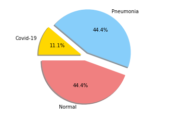

```python
labels = 'Covid-19', 'Normal', 'Pneumonia'
#Now we have a list of 3 elements with counts of images in each label
sizes = [len(data[data["encoded_labels"] == 0]),
         len(data[data["encoded_labels"] == 1]),
         len(data[data["encoded_labels"] == 2])]
colors = ['gold', 'lightcoral', 'lightskyblue']
explode = (0.1, 0.1, 0.1)

# Plot
#We can draw a pie plot using the following statement, more details found in
#the matplotlib documentation
plt.pie(sizes, explode=explode, labels=labels, colors=colors,
autopct='%1.1f%%', shadow=True, startangle=140)

plt.axis('equal')
plt.show()
```

We select batchsize to be 32. 70% of the data is used for training whereas the other 30% is used for validation. The images are normalized before they are fed into the network

```python
#It is a good practice to define your data training parameters like this
#as it becomes easy to change them
batch_size = 32
validation_split = 0.3
shuffle_dataset = True
random_seed= 53
```

Keeping up so far? Do not let the next part confuse you. We use our train:val ratio to find which index would satisfy that ratio. After finding the ratio, we will shuffle the whole dataset and will split the shuffled dataset according to the calculated split index. In this way, we will have a random fraction of the dataset as the training set, and another one as the validation set.

```python
dataset_size = len(data)
indices = list(range(dataset_size))
split = int(np.floor(validation_split * dataset_size))
if shuffle_dataset :
    np.random.seed(random_seed)
    np.random.shuffle(indices)
train_indices, val_indices = indices[split:], indices[:split]
```

# The PyTorch part

Now, with all that boilerplate out of the way, we can move on the PyTorch portion. You were warned, you'll have to deal with the Python scientific computing ecosystem a lot while doing machine learning in Python and thus PyTorch.

## Tensors

Tensors are objects in PyTorch which represent any n-dimensional array of numbers. They can be said to be the most basic building block of PyTorch programs, as nearly all operations are carried out on tensors. To operate on our images, we need to convert them to tensors.

## Transforms

Transforms are basically functions, in the mathematical sense, they take an input and convert it into a specific form, that's more convenient to handle. Here, we use transforms to convert our image data to a tensor, and normalize it. We define our specific transform as a composition, a chain of transforms applied one after the other.

```python
transform = transforms.Compose(
    [transforms.ToTensor(),
     transforms.Normalize((0.5,), (0.5,))
     ])
#The normalize transform normalizes the data so that it is spread around 0.5
#with a standard deviation of 0.5.
```

```python
#Since we already have random subsets of the original data for use as training
#data and validation data, we use the SubsetRandomSampler to get random subsets
#of each of those split datasets.
#This is useful for batching, as these are iterables that give random subsets
#of data in such a way that data is not repeated between batches
train_sampler = SubsetRandomSampler(train_indices)
valid_sampler = SubsetRandomSampler(val_indices)
```

## The Dataset object

PyTorch allows us to abstract our datasets in the form of subclasses of *Dataset* objects. The original Dataset class is part of the PyTorch library. The point of this abstraction is that *Dataset* objects can be iterated over conveniently using DataLoader objects.

To define a Dataset, we only need to create a subclass of a Dataset class, and define 3 methods:

- __init__()
- __getitem__()
- __len__()

We will now define a Dataset that contains the data from the dataframe.

```python
import cv2
class Chest_Xray_Dataset(Dataset):
    def __init__(self, img_data,img_path,transform=None):
        #This field simply stores directory where all the images are stored.
        self.img_path = img_path
        #This field contains the transform,
        #that will be applied to each data item
        self.transform = transform
        #This field contains the image data, or in this case, our dataframe
        self.img_data = img_data

    def __len__(self):
        #The total number of images is simply equal to the length of the
        #dataframe
        return len(self.img_data)

    def __getitem__(self, index):
        #The final image path is the path of the image folder, in which there
        #are three folders corresponding to the label names stored in
        #the dataframe, after which comes the name of the image file.
        #We join them together
        img_name = os.path.join(self.img_path,self.img_data.loc[index, 'labels'],
                                self.img_data.loc[index, 'Images'])
        #This is a PIL image object, and the open method is provided
        #by the library
        image = Image.open(img_name)
        #Since some of our images are grayscale, we convert all of them to
        #grayscale so that our dataset is uniform (which is important in ML)
        image = image.convert('L')
        #Similarly, they should be of the same size
        image = image.resize((300,300))
        #A PIL image can not be directly converted to a tensor, we convert
        #it into a numpy array first
        image = np.array(image, dtype=np.uint8)
        #The numerical label is already stored in the dataframe
        #We convert that single number to a tensor too, so that PyTorch can
        #seemlessly make batch vectors.
        label = torch.tensor(self.img_data.loc[index, 'encoded_labels'])
        if self.transform is not None:
            image = self.transform(image)
        return image, label

dataset = Chest_Xray_Dataset(data,BASE_PATH,transform)
```

## DataLoaders!

We will readily see the utility of making samples, defining batch size as an easy to see configuration variable as we make DataLoaders. DataLoaders require samplers, a specification of the batch size, and of course the *DataSet object* they are loading. The DataLoader will load the data in batches on its own, according to our selected sampling mechanism.

```python
train_loader = torch.utils.data.DataLoader(dataset, batch_size=batch_size,
                                           sampler=train_sampler)
validation_loader = torch.utils.data.DataLoader(dataset, batch_size=batch_size,
                                                sampler=valid_sampler)
```

### Images are still images in tensor form

In the following code snippet, we will show a random sample of images selected by our DataLoaders. We will need to reverse any transforms if we applied them to our data to convert to tensor.

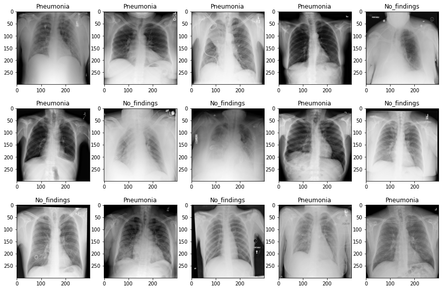

```python
def img_display(img):
    img = img / 2 + 0.5    #unnormalizing the data
    npimg = img.numpy()
    npimg = npimg.squeeze()
    return npimg

# get some random training images
dataiter = iter(train_loader)
images, labels = dataiter.next()
chest_xray_types = {0: 'Covid-19', 1: 'No_findings', 2: 'Pneumonia'}
# Viewing data examples used for training
fig, axis = plt.subplots(3, 5, figsize=(15, 10))

for i, ax in enumerate(axis.flat):
    with torch.no_grad():
        image, label = images[i], labels[i]
        ax.imshow(img_display(image),cmap='gray')
        ax.set(title = f"{chest_xray_types[label.item()]}")
```

## The Network

The following section is perhaps the crux of any ML project written in PyTorch, the part where we actually define our network. The layers (and thus their internal variables) have to be defined when the object is created, and thus they have to be defined in the **__init__()** method. The other method that we define is the forward method. We have to define what operations will be carried out in each layer of the network in the forward pass in this method. The PyTorch library automatically figures out the backward pass from our definition and uses it in the training phase.

```python
class OtherNet(nn.Module):
  #A simple NN with conv and pooling layers, as well as fully connected layers
  #at the end

  def __init__(self):
      super(OtherNet, self).__init__()
      self.conv1= nn.Conv2d(1,32,(3,3))
      self.pool1= nn.MaxPool2d(2,2)

      self.conv2=nn.Conv2d(32,32,(3,3))
      self.fc1= nn.Linear(170528,128)
      self.fc2= nn.Linear(128,3)


  def forward(self,x):
    #We should note here that the x value recieved here is a batched tensor
    #The first dimension of this x tensor is the batch size.
    x=F.relu(self.conv1(x))
    x=self.pool1(x)
    x=F.relu(self.conv2(x))
    x=self.pool1(x)

    x=x.view(x.shape[0],-1)
    x=F.relu(self.fc1(x))
    x=F.log_softmax(self.fc2(x),dim = 1)

    return x

model=OtherNet()
model.to(device) #The device variable is the way to write device agnostic code
#in PyTorch and this is how. We move our data and model to our selected device
#and the selection is made based on availabilty while preferring a GPU.

#PyTorch provides many common loss functions, in this case, we will use the
#cross entropy loss
criterion = nn.CrossEntropyLoss()

#Similarly, PyTorch provides many different kind of optimizers as well
#We will use the Adam optimizer here
optimizer=optim.Adam(model.parameters())
print(model)
```

```
OtherNet(
  (conv1): Conv2d(1, 32, kernel_size=(3, 3), stride=(1, 1))
  (pool1): MaxPool2d(kernel_size=2, stride=2, padding=0, dilation=1, ceil_mode=False)
  (conv2): Conv2d(32, 32, kernel_size=(3, 3), stride=(1, 1))
  (fc1): Linear(in_features=170528, out_features=128, bias=True)
  (fc2): Linear(in_features=128, out_features=3, bias=True)
)
```

```python
#We will use this function to show accuracy after each training run, so we know
#what's happening at each step
def accuracy(out, labels):
    _,pred = torch.max(out, dim=1)
    return torch.sum(pred==labels).item()
```

## Training

This is the training loop. Do not be intimidated by the length, most training loops are similar to this one and minor changes in this one can help you make your own training loop.

```python
#This is the total number of training epochs
n_epochs = 12
#The loop will output a progress text after every 10 batches
print_every = 10

valid_loss_min = np.Inf
val_loss = []
val_acc = []
train_loss = []
train_acc = []
total_step = len(train_loader)
for epoch in range(1, n_epochs+1):
    running_loss = 0.0
    # scheduler.step(epoch)
    correct = 0
    total=0
    print(f'Epoch {epoch}\n')

    #Here our train loader will be used. The train loader gives data in batches
    for batch_idx, (data_, target_) in enumerate(train_loader):
        #This is our device agnostic code, we move both the input and output
        #data to the gpu, in almost the same way as we moved the model.
        data_, target_ = data_.to(device), target_.to(device)

        # zero the parameter gradients
        optimizer.zero_grad()

        # calling the model object on the data calls the forward function
        outputs = model(data_)

        # criterion is the name for our defined loss function
        loss = criterion(outputs, target_)

        # calling this function updates the gradient information for each
        # model parameter
        loss.backward()

        # the step function in the optimizer updates all parameters according
        # to the computed gradient using the backward function
        optimizer.step()

        # the running loss list stores each of our loss values during every
        # optimization step
        running_loss += loss.item()

        # The output is the label with the highest probability
        _,pred = torch.max(outputs, dim=1)

        # The number of correct results is calculated as follows
        correct += torch.sum(pred==target_).item()
        total += target_.size(0)

        # And it can be used to calculate the accuracy of the model at each step
        if (batch_idx) % print_every == 0:
            #After every 10 batches, print model state
            print ('Epoch [{}/{}], Step [{}/{}], Loss: {:.4f}'
                   .format(epoch, n_epochs, batch_idx, total_step, loss.item()))

    # Training accuracy and loss for the whole epoch is stored and output here
    train_acc.append(100 * correct / total)
    train_loss.append(running_loss/total_step)
    print(f'\ntrain loss: {np.mean(train_loss):.4f}, train acc: {(100 * correct / total):.4f}')

    #Now we do almost the same thing for evaluation, with one minor difference
    #Gradients don't need to be calculated during validation, and are thus
    #turned off using the torch.no_grad context manager
    batch_loss = 0
    total_t=0
    correct_t=0
    with torch.no_grad():
        model.eval()
        for data_t, target_t in (validation_loader):
            data_t, target_t = data_t.to(device), target_t.to(device)# on GPU
            outputs_t = model(data_t)
            loss_t = criterion(outputs_t, target_t)
            batch_loss += loss_t.item()
            _,pred_t = torch.max(outputs_t, dim=1)
            correct_t += torch.sum(pred_t==target_t).item()
            total_t += target_t.size(0)
        val_acc.append(100 * correct_t / total_t)
        val_loss.append(batch_loss/len(validation_loader))
        network_learned = batch_loss < valid_loss_min
        print(f'validation loss: {np.mean(val_loss):.4f}, validation acc: {(100 * correct_t / total_t):.4f}\n')

        if network_learned:
            # We save the model whenever we see improvement in the model
            # validation accuracy
            valid_loss_min = batch_loss
            torch.save(model.state_dict(), 'model_classification_tutorial.pt')
            print('Detected network improvement, saving current model')
    model.train()
```

[output not shown]

[output cut: 43 more lines]

[output not shown]

### Accuracy and Loss

Our model has been trained and now we can plot

1. the training and validation loss
2. the training and validation accuracy

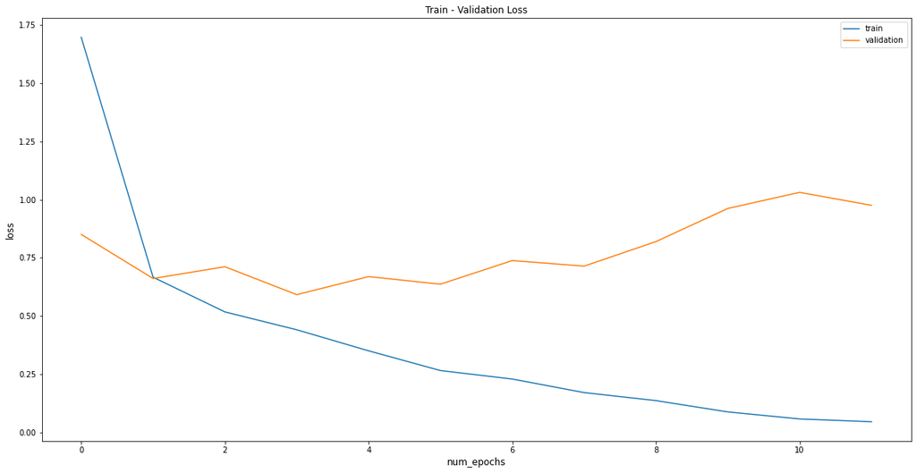

```python
fig = plt.figure(figsize=(20,10))
plt.title("Train - Validation Loss")
plt.plot( train_loss, label='train')
plt.plot( val_loss, label='validation')
plt.xlabel('num_epochs', fontsize=12)
plt.ylabel('loss', fontsize=12)
plt.legend(loc='best')
```

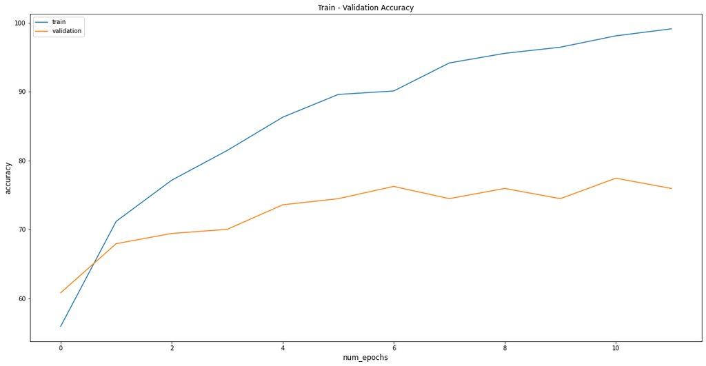

```python
fig = plt.figure(figsize=(20,10))
plt.title("Train - Validation Accuracy")
plt.plot(train_acc, label='train')
plt.plot(val_acc, label='validation')
plt.xlabel('num_epochs', fontsize=12)
plt.ylabel('accuracy', fontsize=12)
plt.legend(loc='best')
```

We can load our model here. During training, we saved the model with the best performance (i.e. with the lowest validation loss)

```python
model.load_state_dict(torch.load('model_classification_tutorial.pt'))
```

```
<All keys matched successfully>
```

### Visualization

The last part in this section involves evaluating the model through visualisation. This part should be mostly self explanatory. Some X-ray chest images are displayed below along with their labels:

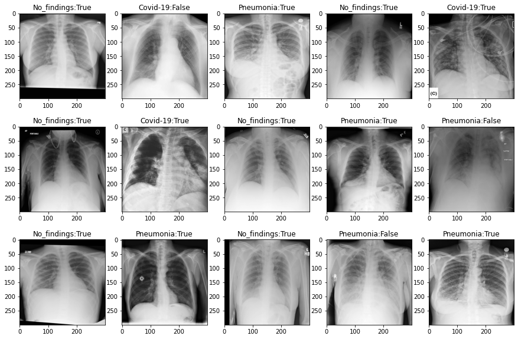

```python
dataiter = iter(validation_loader)
images, labels = dataiter.next()
chest_xray_types = {0: 'Covid-19', 1: 'No_findings', 2: 'Pneumonia'}
# Viewing data examples used for training
fig, axis = plt.subplots(3, 5, figsize=(15, 10))
with torch.no_grad():
    model.eval()
    for ax, image, label in zip(axis.flat,images, labels):
        ax.imshow(img_display(image),cmap="gray")
        image_tensor = image.unsqueeze_(0)
        image_tensor = image_tensor.to(device)
        output_ = model(image_tensor)
        output_ = output_.argmax()
        k = output_.item()==label.item()
        ax.set_title(str(chest_xray_types[label.item()])+":" +str(k))
```